# Lecture 3: Glioma and the Cytokine Profile

This session is based on the paper,

Nijaguna, M.B., Patil, V., Hegde, A.S., Chandramouli, B.A., Arivazhagan, A., Santosh, V. and Somasundaram, K., 2015.  
**An eighteen serum cytokine signature for discriminating glioma from normal healthy individuals.**  
PloS one, 10(9), p.e0137524.

The paper can be found at https://journals.plos.org/plosone/article?id=10.1371/journal.pone.0137524 and the authors have made their data available by placing two Excel files in the dryad repository (https://datadryad.org/) at https://datadryad.org/stash/dataset/doi:10.5061/dryad.8jq92.

Gliomas are a type of brain tumour with a poor survival rate. In this study healthy patients were compared with patients with grade II tumours (Diffuse Astrocytomas, DA), grade III tumours (Anaplastic Astrocytomas, AA) and grade IV timours (Glioblastomas, GBM). Blood samples were taken and the levels of 48 different cytokines were measured. Cytokines are small molecules used to pass signals between cells. They are often associated with the immune system and are indicators of inflammation or infection.

The aim of the study was to assess whether the profile of cytokine levels would help distinguish between healthy patients and the different grades of gliomas.

In this session we will cover,

- Working with lists
- Blocks of code within a pipe
- ifelse()
- Data joins
- Plotting with factors
- Repeating the same calculation
- Model fitting within a pipe

# Working with lists

A `list` is a data object that contains other data objects. A `list` can be thought of as a vector of objects of different types.

Lists are particularly important because functions in R are only allowed to return a single object. Most functions make a host of calculations and pack their results into a list, which they return. If you want to use a complex function, then you need to be able to handle the returned list.

## Creating a list

The objects in the list may be given `internal names` when the list is created. Here `a` is a single number that is saved in the list with the internal name `count`.

```r
a  <- 3
b  <- c("London", "Sydney")
c  <- c(3, 4, 5, 6)

myList <- list(count   = a,
               cities  = b,
               numbers = c)

print(myList)
```

```
## $count
## [1] 3
##
## $cities
## [1] "London" "Sydney"
##
## $numbers
## [1] 3 4 5 6
```

Objects can be extracted `by name` using the `$` notation by writing `listName$internalName`. For example,

```r
myList$cities
```

```
## [1] "London" "Sydney"
```

Objects can also be extracted `by position` using double square brackets `[[ ]]`

```r
myList[[2]]
```

```
## [1] "London" "Sydney"
```

It is possible to create a list without specifying internal names, in which case extraction by position is the only option.

```r
mySecondList <- list(a, b, c)

print(mySecondList)
```

```
## [[1]]
## [1] 3
##
## [[2]]
## [1] "London" "Sydney"
##
## [[3]]
## [1] 3 4 5 6
```

## Unpacking a list

To unpack a list, you must first discover what it contains.

As an example, consider the list returned by the `t.test()` function.

```r
tibble( id    = 1:8,
        sex   = rep(c("m", "f"), each=4),
        sbp   = c(135, 125, 120, 115, 155, 140, 140, 135)) %>%
  print() %>%
  t.test(sbp ~ sex, data = .) -> myT
```

```
## # A tibble: 8 × 3
##      id sex     sbp
##   <int> <chr> <dbl>
## 1     1 m       135
## 2     2 m       125
## 3     3 m       120
## 4     4 m       115
## 5     5 f       155
## 6     6 f       140
## 7     7 f       140
## 8     8 f       135
```

```r
print(myT)
```

```
##
##  Welch Two Sample t-test
##
## data:  sbp by sex
## t = 3.0833, df = 5.9988, p-value = 0.02158
## alternative hypothesis: true difference in means between group f and group m is not equal to 0
## 95 percent confidence interval:
##   3.869492 33.630508
## sample estimates:
## mean in group f mean in group m
##          142.50          123.75
```

The `t.test()` calculates many values, `t`, `df`, `p-value`, `confidence limits` etc. The `print()` function unpacks this list and prints it in a readable form.

The structure of the list can be discovered using the `str()` function

```r
str(myT)
```

```
## List of 10
##  $ statistic  : Named num 3.08
##   ..- attr(*, "names")= chr "t"
##  $ parameter  : Named num 6
##   ..- attr(*, "names")= chr "df"
##  $ p.value    : num 0.0216
##  $ conf.int   : num [1:2] 3.87 33.63
##   ..- attr(*, "conf.level")= num 0.95
##  $ estimate   : Named num [1:2] 142 124
##   ..- attr(*, "names")= chr [1:2] "mean in group f" "mean in group m"
##  $ null.value : Named num 0
##   ..- attr(*, "names")= chr "difference in means between group f and group m"
##  $ stderr     : num 6.08
##  $ alternative: chr "two.sided"
##  $ method     : chr "Welch Two Sample t-test"
##  $ data.name  : chr "sbp by sex"
##  - attr(*, "class")= chr "htest"
```

`myT` is a list of 10 items with internal names, `statistic`, `parameter` etc., so the items can be extracted using the $ notation.

```r
myT$p.value
```

```
## [1] 0.02157595
```

or the double square bracket notation

```r
myT[[3]]
```

```
## [1] 0.02157595
```

## Attributes

The structure of `myT` showed that some of the objects in the returned list have `attributes`, denoted by `attr`.

An attribute is a piece of *metadata* stored alongside a data object. Metadata is any information that helps us understand the data object.

Let’s create a simple vector of length measurements and save the unit of measurement as a piece of metadata.

```r
width <- c(7.5, 12.25, 9.75)
attr(width, "units") <- "cm"

str(width)
```

```
##  num [1:3] 7.5 12.25 9.75
##  - attr(*, "units")= chr "cm"
```

To extract an attribute, we use its name

```r
attr(width, "units")
```

```
## [1] "cm"
```

In the case of the t-test, the data object `conf.int` also has an attribute

```r
str(myT$conf.int)
```

```
##  num [1:2] 3.87 33.63
##  - attr(*, "conf.level")= num 0.95
```

The CI for the difference in mean SBP, women - men, is (3.87, 33.63) and the attribute tells us that this is a 95% CI.

# Blocks of code in a pipe

### The basic dot notation

We saw in lecture 1 that the dot notation is used when the input is `not the first` argument of the next function. So

```r
x %>%
  f(y, ., z)
```

is equivalent to `f(y, x, z)`.

### Dots in curly brackets

When the next line(s) of code are wrapped in curly brackets {}, the dot still stands for the input, but it does not need to be the argument of a function.

In this example, I extract the estimate and its attribute from a t-test and paste them together into a single string using the `paste()` function.

```r
myT %>%
  {
    # extract the estimate
    e    <- .$estimate
    # extract the names attribute of the estimate
    desc <- attr(.$estimate, "names")
    # paste together the 1st estimate and the 1st name
    paste(desc[1], "=", e[1])
  }  %>%
  print()
```

```
## [1] "mean in group f = 142.5"
```

Within the block defined by the curly brackets,

- the dot always refers to the object passed into the block
- the dot may be used multiple times
- the dot does not need to be an argument of a function

Often blocks are used when there is only one line of code, but the passed object is not a function’s argument. Here is a slightly artificial example,

```r
myT %>%
  { .$p.value } %>%
  round(4) %>%
  print()
```

```
## [1] 0.0216
```

# Conditional changes with `ifelse()`

`ifelse()` is used to change selected items in a vector. The general syntax is

```r
ifelse( CONDITION, VALUE IF TRUE, VALUE IF FALSE)
```

Here is a simple example in which negative values are replaced by missing values.

```r
# the test vector
x <- c( 3, -2, 4, 6, -5)

# if x < 0 use the value NA, else use the value from x
ifelse( x < 0, NA, x)
```

```
## [1]  3 NA  4  6 NA
```

Often `ifelse()` is used inside `dplyr`’s `mutate()`

Suppose that the data in `sbpDF` were sent to me by a colleague, but that subsequently I discovered that subject 7’s correct age is 53 and not 35. It would not be reproducible if I edited the data manually, so I make the change in a script.

```r
# Original data
tibble( id    = 1:8,
        sex   = c("m", "f", "m", "m", "f", "f", "f", "f"),
        age   = c( 45,  37,  25,  36,  52,  29,  35,  48),
        sbp   = c(135, 130, 120, 115, 155, 140, 145, 135) ) %>%
    mutate( sex = factor(sex, levels = c("m", "f"),
                            labels = c("male", "female"))) -> rawDF

# correct the age of subject 7
rawDF %>%
  mutate( age = ifelse( id == 7, 53, age) ) %>%
  print() -> sbpDF
```

```
## # A tibble: 8 × 4
##      id sex      age   sbp
##   <int> <fct>  <dbl> <dbl>
## 1     1 male      45   135
## 2     2 female    37   130
## 3     3 male      25   120
## 4     4 male      36   115
## 5     5 female    52   155
## 6     6 female    29   140
## 7     7 female    53   145
## 8     8 female    48   135
```

# Data Joins

A `join` is a method for collecting together data from two data frames.

My example combines data from two visits in a longitudinal study of blood pressure. Here is the baseline (visit 1) patient data

```r
# data from visit 1
tibble( id     = 1:5,
        age    = c(32, 45, 72, 37, 55),
        sex    = c("m", "m", "f", "f", "m"),
        sbp_v1 = c(120, 135, 125, 140, 125)) %>%
  print()   -> visit1DF
```

```
## # A tibble: 5 × 4
##      id   age sex   sbp_v1
##   <int> <dbl> <chr>  <dbl>
## 1     1    32 m        120
## 2     2    45 m        135
## 3     3    72 f        125
## 4     4    37 f        140
## 5     5    55 m        125
```

and here is the follow-up data from visit 2. Patient 3 was lost to follow-up and patient 6 missed the baseline visit.

```r
# data from visit 2
tibble( id     = c(1, 2, 4, 5, 6),
        sbp_v2 = c(125, 130, 150, 135, 130)) %>%
  print()   -> visit2DF
```

```
## # A tibble: 5 × 2
##      id sbp_v2
##   <dbl>  <dbl>
## 1     1    125
## 2     2    130
## 3     4    150
## 4     5    135
## 5     6    130
```

Both data frames contain and identifier `id` that can be used to match up the subject. The variable(s) used for matching data frames are called `keys`.

In the language of the tidyverse, data frames are combined using a **join**

The general syntax for joining data frames A and B is

```r
join(A, B, by = "key")
```

Every `join` must allow for the possibility that a match is missing from one or other of the data frames.

The six different joins are illustrated using `visit1DF` and `visit2DF`. It is unlikely that you will remember the definitions of the six joins, just look them up when you need them.

### left_join()

The most widely used join is `left_join()`, which combines all of the rows of A and any matches from B

```r
left_join(visit1DF, visit2DF, by = "id")
```

```
## # A tibble: 5 × 5
##      id   age sex   sbp_v1 sbp_v2
##   <dbl> <dbl> <chr>  <dbl>  <dbl>
## 1     1    32 m        120    125
## 2     2    45 m        135    130
## 3     3    72 f        125     NA
## 4     4    37 f        140    150
## 5     5    55 m        125    135
```

`left_join` keeps all the rows of visit1DF, so a missing value is inserted in the follow-up data for patient 3.

### right_join()

combines all of the rows of B and any matches from A

```r
right_join(visit1DF, visit2DF,  by = "id")
```

```
## # A tibble: 5 × 5
##      id   age sex   sbp_v1 sbp_v2
##   <dbl> <dbl> <chr>  <dbl>  <dbl>
## 1     1    32 m        120    125
## 2     2    45 m        135    130
## 3     4    37 f        140    150
## 4     5    55 m        125    135
## 5     6    NA <NA>      NA    130
```

Since only the follow-up rows are kept, patient 3 is dropped.

### full_join()

combines all of the rows found in either A or B.

```r
full_join(visit1DF, visit2DF, by = "id")
```

```
## # A tibble: 6 × 5
##      id   age sex   sbp_v1 sbp_v2
##   <dbl> <dbl> <chr>  <dbl>  <dbl>
## 1     1    32 m        120    125
## 2     2    45 m        135    130
## 3     3    72 f        125     NA
## 4     4    37 f        140    150
## 5     5    55 m        125    135
## 6     6    NA <NA>      NA    130
```

### inner_join()

only combines the rows present in both A and B

```r
inner_join(visit1DF, visit2DF, by = "id")
```

```
## # A tibble: 4 × 5
##      id   age sex   sbp_v1 sbp_v2
##   <dbl> <dbl> <chr>  <dbl>  <dbl>
## 1     1    32 m        120    125
## 2     2    45 m        135    130
## 3     4    37 f        140    150
## 4     5    55 m        125    135
```

### semi_join()

extracts the rows of A that have a match in B (but the information from B not included)

```r
semi_join(visit1DF, visit2DF, by = "id")
```

```
## # A tibble: 4 × 4
##      id   age sex   sbp_v1
##   <int> <dbl> <chr>  <dbl>
## 1     1    32 m        120
## 2     2    45 m        135
## 3     4    37 f        140
## 4     5    55 m        125
```

### anti_join()

extracts the rows rows of A that do not have a match in B

```r
anti_join(visit1DF, visit2DF, by = "id")
```

```
## # A tibble: 1 × 4
##      id   age sex   sbp_v1
##   <int> <dbl> <chr>  <dbl>
## 1     3    72 f        125
```

# Plotting factors with ggplot2

## Bar Plots

Bar plots (also called bar charts) are the simplest way of plotting a factor.

There are two types of bar plot

- Type I: plots the frequencies, e.g. number of men and number of women
- Type II: plots some calculated statistic, e.g. mean ages of men and women

### Bar plot of frequency

In the example, the bar height represents the number of men and women in the `sbpDF` data frame.

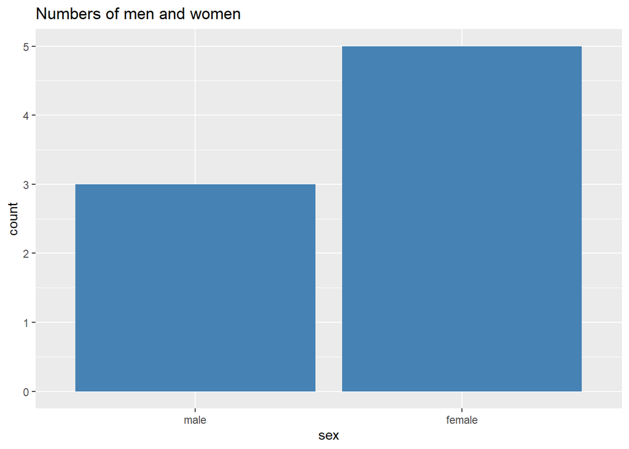

```r
# Type I bar plot of sex
sbpDF %>%
  ggplot( aes(x = sex)) +
  geom_bar( fill = "steelblue") +
  labs(title = "Numbers of men and women")
```

### Bar plot of a statistic

The bar height shows the average systolic blood pressure of men and women

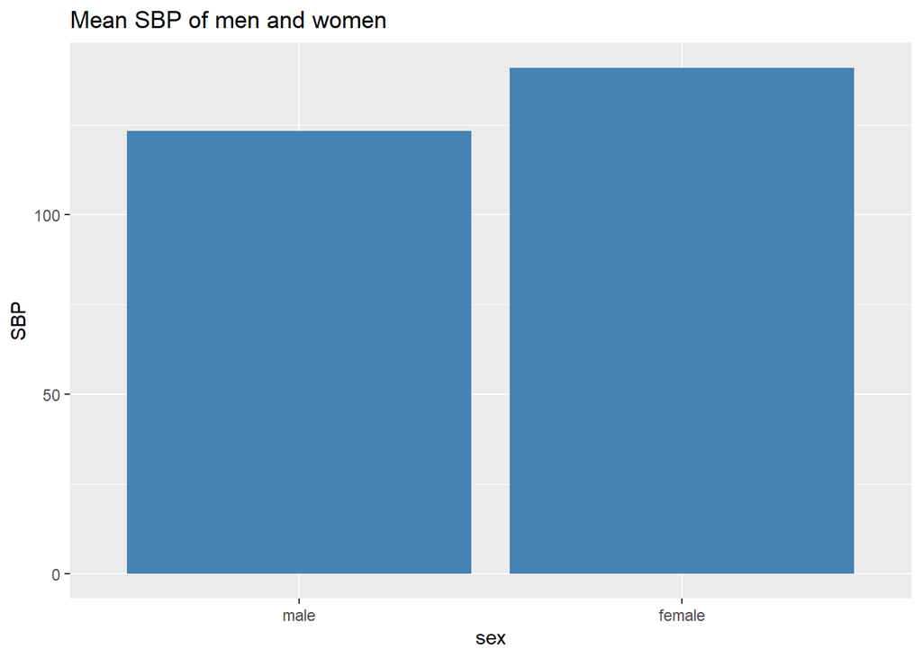

```r
# Type II bar plot of the average sbp by sex
sbpDF %>%
  group_by( sex ) %>%
  summarise( SBP = mean(sbp)) %>%
  ggplot( aes(x = sex, y = SBP)) +
  geom_bar( stat = "identity", fill = "steelblue") +
  labs(title = "Mean SBP of men and women")
```

## Boxplots

Boxplots are more informative than type II bar plots as they show the distribution of the variable of interest rather than a single statistic.

The box shows the range of the middle 50% of the data with a horizontal line at the median. The lines extend to the range of the data, with any outliers shown as single points.

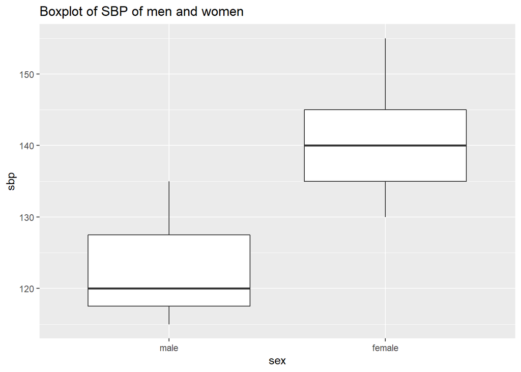

```r
# Boxplot of sbp by sex
sbpDF %>%
  ggplot( aes(x = sex, y = sbp)) +
  geom_boxplot() +
  labs(title = "Boxplot of SBP of men and women")
```

# Repeating calculations

Loops are a way of repeating a calculation. As an example, suppose that we wanted to draw a bootstrap sample from the `sbpDF` in order to calculate the bootstrap median blood pressure.

The function `sample_n()` draws a sample of fixed size from the rows of a data frame.

```r
# seed so that the random draw is reproducible
set.seed(982)

# code to select a random bootstrap sample
sbpDF %>%
  sample_n(size = 8, replace = TRUE) %>%
  print() %>%
  summarise( m = median(sbp)) %>%
  print()
```

```
## # A tibble: 8 × 4
##      id sex      age   sbp
##   <int> <fct>  <dbl> <dbl>
## 1     8 female    48   135
## 2     2 female    37   130
## 3     6 female    29   140
## 4     7 female    53   145
## 5     3 male      25   120
## 6     2 female    37   130
## 7     2 female    37   130
## 8     3 male      25   120
## # A tibble: 1 × 1
##       m
##   <dbl>
## 1   130
```

A proper bootstrap analysis would repeat this process many times and look at the distribution of the medians. We could do this with a `for` loop

```r
# set seed for reproducibility
set.seed(982)

# draw 5 bootstrap samples
for( i in 1:5 ) {
  sbpDF %>%
    sample_n(size = 8, replace = TRUE) %>%
    summarise( m = median(sbp)) %>%
    print()
}
```

```
## # A tibble: 1 × 1
##       m
##   <dbl>
## 1   130
## # A tibble: 1 × 1
##       m
##   <dbl>
## 1   135
## # A tibble: 1 × 1
##       m
##   <dbl>
## 1  138.
## # A tibble: 1 × 1
##       m
##   <dbl>
## 1   135
## # A tibble: 1 × 1
##       m
##   <dbl>
## 1  138.
```

Here `i` is an index and runs from 1 to 5, so the contents of the loop enclosed in the curly brackets are repeated 5 times. `i` is a popular name for the index but you could call it anything you like.

## Accumulating results

Often when we repeat a calculation in a loop, we want to collect the results and save them in a new data object

It is important to create the data object for saving the results `before` entering the loop.

In this code, `pull()` is used to extract a column from the data frame so that it can be saved elsewhere.

```r
# data frame for saving 100 bootstrap medians
tibble( index  = 1:100,
        median = rep(NA, 100)) %>%
  print() -> resultsDF
```

```
## # A tibble: 100 × 2
##    index median
##    <int> <lgl>
##  1     1 NA
##  2     2 NA
##  3     3 NA
##  4     4 NA
##  5     5 NA
##  6     6 NA
##  7     7 NA
##  8     8 NA
##  9     9 NA
## 10    10 NA
## # … with 90 more rows
## # ℹ Use `print(n = ...)` to see more rows
```

```r
# seed for reproducibility
set.seed(982)

# repeat the calculation 100 times
for( i in 1:100 ) {
  sbpDF %>%
    sample_n(size = 8, replace = TRUE) %>%
    summarise( m = median(sbp)) %>%
    pull(m)  -> resultsDF$median[i]
}

# summarise the results
resultsDF %>%
  print() %>%
  summarise( m = mean(median),
             s = sd(median)) %>%
  print()
```

```
## # A tibble: 100 × 2
##    index median
##    <int>  <dbl>
##  1     1   130
##  2     2   135
##  3     3   138.
##  4     4   135
##  5     5   138.
##  6     6   142.
##  7     7   142.
##  8     8   138.
##  9     9   138.
## 10    10   130
## # … with 90 more rows
## # ℹ Use `print(n = ...)` to see more rows
## # A tibble: 1 × 2
##       m     s
##   <dbl> <dbl>
## 1  134.  5.21
```

s is the bootstrap standard error of the median.

### More on loops

`for` loops belong in base R and there are better ways of repeating calculations in the tidyverse. However,

- loops are widely used because most people learn base R before they meet the tidyverse
- the tidyverse methods for repeating calculations require the use of user-written functions, which are beyond the scope of this introduction.

The tidyverse package for repeating calculations within a pipe is called `purrr`.

# Model Fitting in a Pipe

In R, regression models are fitted using the linear model function `lm()`.

```r
# fit a linear model
sbpDF %>%
  lm( sbp ~ age + sex, data = .) %>%
  print()
```

```
##
## Call:
## lm(formula = sbp ~ age + sex, data = .)
##
## Coefficients:
## (Intercept)          age    sexfemale
##    103.4463       0.5628      12.9013
```

`lm()` comes with its own print format, which is what we have here, but it only shows a small selection of the information returned as a list by `lm()`. You can use `str()` to look at the contents of the returned list but be warned, it is long and complex.

The package `broom` was written to simplify the extraction of information after a model fit. The package has three functions, `tidy()`, `glance()` and `augment()`.

`tidy()` creates a table of regression coefficients.

```r
library(broom)

sbpDF %>%
  lm( sbp ~ age + sex, data = .) %>%
  tidy() %>%
  print()
```

```
## # A tibble: 3 × 5
##   term        estimate std.error statistic  p.value
##   <chr>          <dbl>     <dbl>     <dbl>    <dbl>
## 1 (Intercept)  103.       13.3        7.77 0.000564
## 2 age            0.563     0.348      1.62 0.167
## 3 sexfemale     12.9       7.06       1.83 0.127
```

`glance()` creates measures of goodness of fit

```r
sbpDF %>%
  lm( sbp ~ age + sex, data = .) %>%
  glance() %>%
  print()
```

```
## # A tibble: 1 × 12
##   r.squ…¹ adj.r…² sigma stati…³ p.value    df logLik   AIC   BIC devia…⁴ df.re…⁵
##     <dbl>   <dbl> <dbl>   <dbl>   <dbl> <dbl>  <dbl> <dbl> <dbl>   <dbl>   <int>
## 1   0.671   0.540  8.78    5.10  0.0620     2  -26.9  61.7  62.0    385.       5
## # … with 1 more variable: nobs <int>, and abbreviated variable names
## #   ¹r.squared, ²adj.r.squared, ³statistic, ⁴deviance, ⁵df.residual
## # ℹ Use `colnames()` to see all variable names
```

`augment()` creates fitted values and residuals

```r
sbpDF %>%
  lm( sbp ~ age + sex, data = .) %>%
  augment() %>%
  print()
```

```
## # A tibble: 8 × 9
##     sbp   age sex    .fitted .resid  .hat .sigma .cooksd .std.resid
##   <dbl> <dbl> <fct>    <dbl>  <dbl> <dbl>  <dbl>   <dbl>      <dbl>
## 1   135    45 male      129.   6.23 0.480   8.81 0.298        0.984
## 2   130    37 female    137.  -7.17 0.273   8.87 0.115       -0.958
## 3   120    25 male      118.   2.48 0.501   9.66 0.0538       0.400
## 4   115    36 male      124.  -8.71 0.334   8.24 0.247       -1.22
## 5   155    52 female    146.   9.38 0.306   8.04 0.242        1.28
## 6   140    29 female    133.   7.33 0.545   8.18 0.611        1.24
## 7   145    53 female    146.  -1.18 0.333   9.79 0.00450     -0.164
## 8   135    48 female    143.  -8.36 0.228   8.58 0.116       -1.08
```

Each `broom` function returns a data frame, so we can continue the pipe after a `broom` function has been used

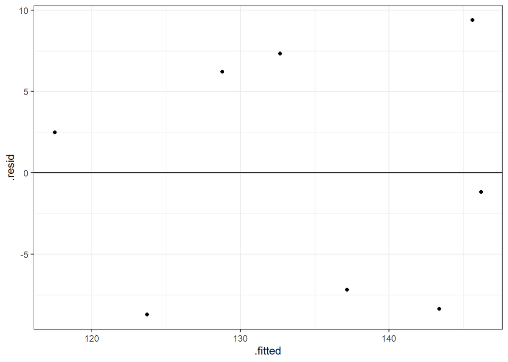

```r
sbpDF %>%
  lm( sbp ~ age + sex, data = .) %>%
  augment() %>%
  ggplot( aes(x = .fitted, y = .resid)) +
  geom_point() +
  geom_hline( yintercept = 0) +
  theme_bw()
```

The `broom` functions work with most of R’s model fitting functions, including,

- `glm()` the function that fits a generalised linear model
- `coxph()` for Cox’s proportional hazards model
- `gam()` for generalised additive models
- `ivreg()` for instrumental variable regression
- `nls()` for non-linear least squares

In total, `broom` works with around 100 model fitting functions.